# Simulation study: when protein identity fails and function does not

Bray-Curtis treats two proteins as either the same accession or maximally different. Metaproteomes break that: samples can differ in function while sharing no accession, and Bray-Curtis cannot tell that apart from any other difference.

Here two groups of samples differ **only** in protein function. Depth, richness and abundance profile are identical by construction, and no accession appears in more than one sample. Three distances are compared: Bray-Curtis, weighted UniFrac on a protein tree, and `weightedRep()` with a TM-Vec ground metric.

The last of those is weighted UniFrac too – the same estimator, on a tree fitted to TM-Vec structural distance instead of to sequence phylogeny. The two UniFrac arms therefore differ in exactly one thing, the tree, which is what makes this a ground-metric ablation rather than a contest between estimators.

```r
Sys.setenv(KMP_DUPLICATE_LIB_OK = "TRUE")
reticulate::use_python(Sys.which("python3"), required = TRUE)

library(phyloseq)
library(Biostrings)
```

```r
library(vegan)
library(ggplot2)
library(gt)
library(here)
for (f in list.files(here("R"), full.names = TRUE)) {source(f)}
set.seed(1)
```

## Data

Two functional groups, each built from **two** Pfam families rather than one, from UniProt via `analysis/fetch_pfam.R`:

| Pfam | family | role | median aa | class | reaction |
| --- | --- | --- | --- | --- | --- |
| PF00162 | PGK | A | 395 | transferase, EC 2.7.2.3 | ATP-dependent phosphoryl transfer |
| PF01546 | Peptidase_M20 | B | 379 | hydrolase, EC 3.4.-.- | zinc-dependent amide hydrolysis |
| PF00406 | Adenylate_kinase | A | 214 | transferase, EC 2.7.4.3 | ATP-dependent phosphoryl transfer |
| PF00293 | Nudix_hydrolase | B | 175 | hydrolase, EC 3.6.1.- | nucleotide pyrophosphohydrolysis |

A single family per group would make family identity and group the same variable, so any family-specific quirk – length included – is perfectly collinear with group and no covariate can separate them. Two families per group breaks that: role A spans both a ~395 aa and a ~214 aa family, role B a ~379 aa and a ~175 aa one, so the only thing consistent within a role is the functional class.

For each role, candidates from its two families (one protein per organism per family, reviewed bacterial UniProt entries) are pooled and 600 are drawn at random (`set.seed(1)`, once, at the top of `fetch_pfam.R`) – no matching of organisms between roles. Length is a consequence of that draw, not a constraint on it, so it is checked below rather than engineered:

```r
universe <- readRDS(here("data", "simulated", "pfam_universe.rds"))
tapply(nchar(universe$seq), universe$role, summary)
```

```
## $A
##    Min. 1st Qu.  Median    Mean 3rd Qu.    Max.
##   174.0   214.0   223.5   299.6   395.0   400.0
##
## $B
##    Min. 1st Qu.  Median    Mean 3rd Qu.    Max.
##   154.0   190.0   375.0   302.4   380.0   399.0
```

## Simulation

30 samples per group. Group A expresses PGK + Adenylate_kinase, group B Peptidase_M20 + Nudix_hydrolase.

- **Proteins.** Each role’s 600 candidates are shuffled once and the first 240 (30 samples x 8 proteins) are dealt out in disjoint slices of 8, so every sample gets a random mix of both families and no accession lands in two samples. The remaining 360 candidates per role stay in `universe` unused – slack for the length check above, not part of the simulation.
- **Abundance.** One weight profile is reused by every sample, then counts are multinomial at a fixed depth.

```r
M <- 8L; DEPTH <- 2000L; N <- 30L

# two columns on purpose: plot_ordination() drops a one-column sample_data and
# then cannot find the variable to colour by
meta <- data.frame(sample = sprintf("s%02d", seq_len(2 * N)),
                   group = rep(c("A", "B"), each = N),
                   row.names = sprintf("s%02d", seq_len(2 * N)))
pool <- lapply(split(universe$protein, universe$role), sample)
prof <- sort(rlnorm(M, 0, 0.6), decreasing = TRUE)

counts <- t(sapply(seq_len(2 * N), function(s) {
  slice <- pool[[meta$group[s]]][((s - 1) %% N) * M + seq_len(M)]
  p <- setNames(numeric(nrow(universe)), universe$protein)
  p[slice] <- prof
  rmultinom(1, DEPTH, p)[, 1]
}))
dimnames(counts) <- list(rownames(meta), universe$protein)

stopifnot(all(rowSums(counts) == DEPTH),             # depth matched
          length(unique(rowSums(counts > 0))) == 1L, # richness matched
          max(colSums(counts > 0)) == 1L)            # no accession in two samples
```

```r
used <- universe[match(colnames(counts), universe$protein), ]
seqs <- AAStringSet(setNames(used$seq, used$protein))
aln  <- DECIPHER::AlignSeqs(seqs, verbose = FALSE)
dm   <- DECIPHER::DistanceMatrix(aln, verbose = FALSE, includeTerminalGaps = FALSE)
dm[is.na(dm)] <- max(dm, na.rm = TRUE)   # unalignable pairs => maximally distant
tree <- ape::as.phylo(as.hclust(DECIPHER::Treeline(myDistMatrix = dm, method = "NJ",
                                                   verbose = FALSE)))
```

Counts, tree, sequences and metadata go into one `phyloseq` object, which is the input to everything below.

```r
ps <- phyloseq(otu_table(counts, taxa_are_rows = FALSE), sample_data(meta),
               phy_tree(tree), refseq(seqs))
saveRDS(ps, here("data", "simulated", "sim_ps.rds"))
ps
```

```
## phyloseq-class experiment-level object
## otu_table()   OTU Table:         [ 1200 taxa and 60 samples ]
## sample_data() Sample Data:       [ 60 samples by 2 sample variables ]
## phy_tree()    Phylogenetic Tree: [ 1200 tips and 1199 internal nodes ]
## refseq()      AAStringSet:      [ 1200 reference sequences ]
```

## Embedding

TM-Vec1: its head was trained to regress the TM-score of protein pairs, so cosine similarity between two vectors is a predicted TM-score.

```r
Z <- embed_proteins(as.character(refseq(ps)), batch_size = 16)[taxa_names(ps), ]
```

## Results

```r
cnt <- as(otu_table(ps), "matrix")

# The ground metric is built once and reused by everything downstream. The
# structure tree is fitted to it with UPGMA (fastcluster, O(n^2)); BIONJ fits
# a non-additive metric better but is O(n^3) and does not survive the scale of
# the case studies, so the same method is used here for comparability.
G    <- tmDist(Z)                                     # 1 - predicted TM-score
tree <- structureTree(G, method = "upgma")
tree_fidelity <- cor(as.vector(G),
                     as.vector(as.dist(ape::cophenetic.phylo(tree)[labels(G), labels(G)])))

D <- list(
  `Bray-Curtis`              = phyloseq::distance(ps, method = "bray"),
  `w-UniFrac (protein tree)` = phyloseq::distance(ps, method = "wunifrac"),
  `weightedRep + TM-Vec1`    = weightedRep(cnt, G, method = "unifrac", tree = tree)
)
```

The two roles are not length-matched by construction (see the length check above), so `group` is tested with each sample’s abundance-weighted mean protein length entered first – the same covariate-adjustment pattern `case_study.Rmd` already uses for dose/sex/age, applied here to rule out length as the source of the separation rather than genuine functional signal. Reporting the raw (unadjusted) $R^2$ alongside it shows how much work the adjustment is actually doing: with a single family per group that gap was large, because family and group were the same variable; with two length scales per group it should be small.

```r
md <- data.frame(sample_data(ps))
len <- setNames(nchar(as.character(refseq(ps))), taxa_names(ps))
md$mean_log_len <- as.numeric((cnt %*% log(len[colnames(cnt)])) / rowSums(cnt))

gt(do.call(rbind, lapply(names(D), function(n) {
  raw <- adonis2(D[[n]] ~ group, data = md, by = "terms", permutations = 9999)
  adj <- adonis2(D[[n]] ~ mean_log_len + group, data = md, by = "terms", permutations = 9999)
  data.frame(distance = n,
             R2_raw = round(raw["group", "R2"], 3),
             R2_adjusted = round(adj["group", "R2"], 3),
             F = round(adj["group", "F"], 2), p = adj["group", "Pr(>F)"])
})))
```

| distance | R2_raw | R2_adjusted | F | p |
| --- | --- | --- | --- | --- |
| Bray-Curtis | 0.017 | 0.017 | 1.00 | 1e+00 |
| w-UniFrac (protein tree) | 0.320 | 0.318 | 28.76 | 1e-04 |
| weightedRep + TM-Vec1 | 0.796 | 0.792 | 334.05 | 1e-04 |

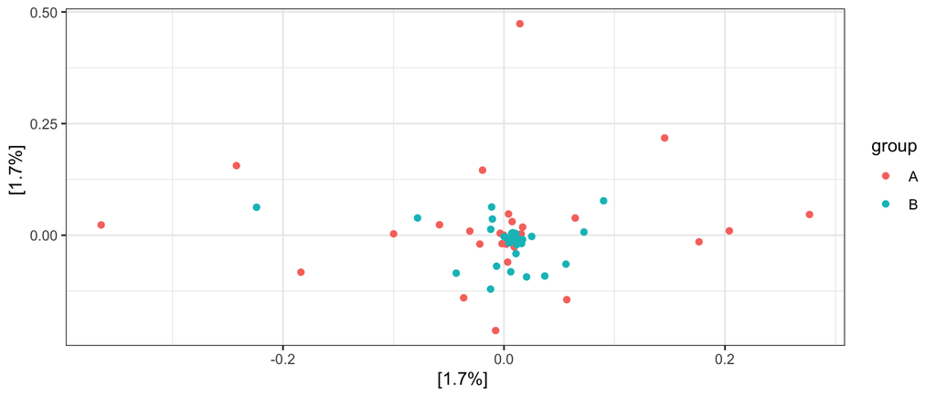

```r
plot_ordination(ps, ordinate(ps, "PCoA", distance = D[["Bray-Curtis"]]), color = "group") + theme_bw()
```

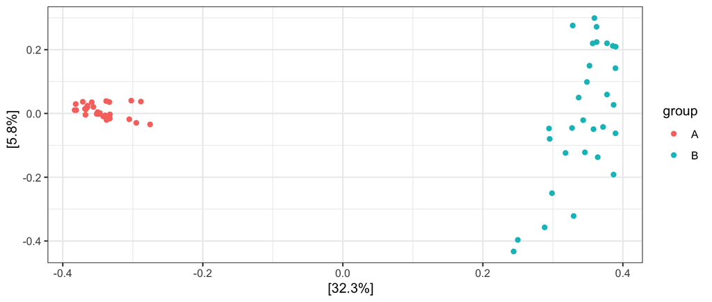

```r
plot_ordination(ps, ordinate(ps, "PCoA", distance = D[["w-UniFrac (protein tree)"]]), color = "group") + theme_bw()
```

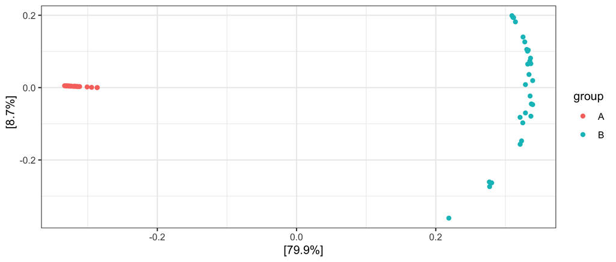

```r
plot_ordination(ps, ordinate(ps, "PCoA", distance = D[["weightedRep + TM-Vec1"]]), color = "group") + theme_bw()
```

## Conclusion

Bray-Curtis returns 1.000 for every pair. A constant distance matrix cannot express any grouping, so PERMANOVA lands on the exact null $1/(n-1) = 0.017$ with $p = 1$. It is not weak here, it is blind: no accession is shared, and accessions are all it reads.

Weighted UniFrac on a protein tree also finds it, at a lower $R^2$. That arm is not a fair fight and should not be quoted as one: none of the four families are homologous to each other, so the alignment behind the tree is largely gap and between-family branch lengths are gap-penalty artifacts rather than measured divergence. A better tree would likely close some of the gap. The claim worth making is applicability — an embedding stays defined where an alignment across non-homologous proteins does not — rather than power.

Two limits. This is the zero-overlap extreme; real metaproteomes share some accessions, and Bray-Curtis regains ability as that overlap rises. And the functional contrast here is total, every protein in one group a transferase and in the other a hydrolase, so the effect size says nothing about realistic ones.